# Лабораторная работа №7

Операционные системы

Серебрякова Д. И.

Российский университет дружбы народов, Москва, Россия

15 марта 2025

## Цель работы

Ознакомление с файловой системой Linux, её структурой, именами и содержанием каталогов. Приобретение практических навыков по применению команд для работы с файлами и каталогами, по управлению процессами (и работами), по проверке использования диска и обслуживанию файловой системы.

## Выполнение лабораторной работы

Выполняю все примеры, приведенные в первой части лабораторной работы (рис. 1).

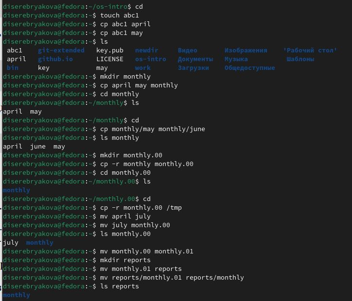

1

## Выполнение лабораторной работы

Продолжаю выполнение примеров (рис. 2).

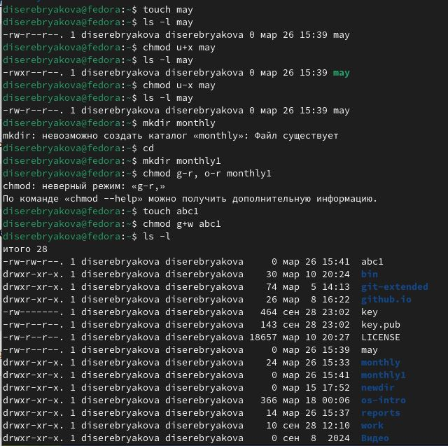

2

## Выполнение лабораторной работы

Проверяю, есть ли необходимый мне файл usr/include/sys/io.h (рис. 3).

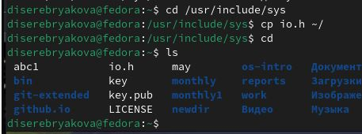

3

## Выполнение лабораторной работы

Копирую файл io.h в домашний каталог и называю его equipment, а также перемещаю файл equipment в каталог ski.plases (рис. 4).

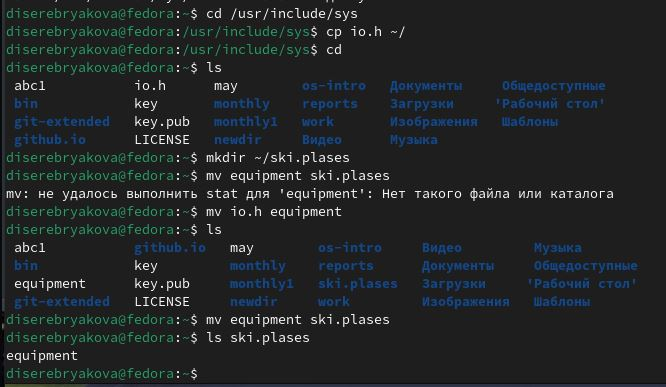

4

## Выполнение лабораторной работы

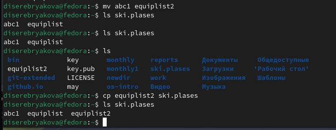

5

## Выполнение лабораторной работы

Создаю и перемещаю каталог newdir в каталог ski.plases и называю его plans (рис. 6).

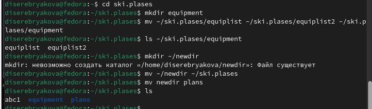

6

## Выполнение лабораторной работы

Изменяю права доступа некоторым файлам (рис. 7).

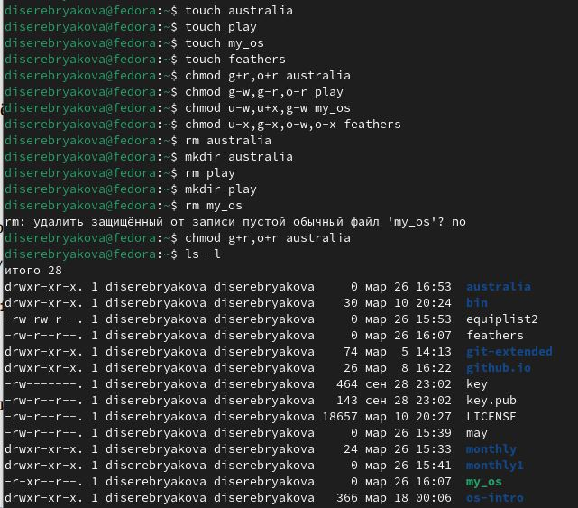

7

## Выполнение лабораторной работы

Пробую просмотреть содержимое файла etc/password (рис. 8).

[figure not shown]

8

## Выполнение лабораторной работы

Копирую файл feathers в файл file.old. Перемещаю файл file.old в каталог play. Копирую каталог play в каталог fun и перемещаю каталог fun в каталог play, назвав его games (рис.10).

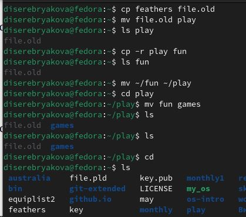

10

## Выполнение лабораторной работы

ДПредоставляю владельцу файла feathers право на чтение. Лишаю владельца каталога play права на выполнение. Пробую перейти в каталог play. Предоставляю владельцу каталога play право на выполнение (рис. 11).

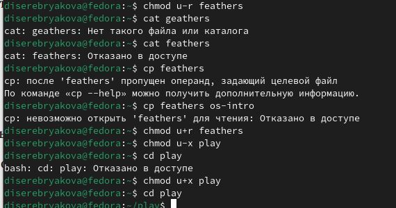

11

## Выполнение лабораторной работы

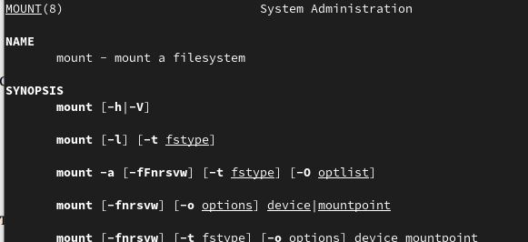

12

## Выводы

В ходе работы я ознакомилась с файловой системой Linux, её структурой, именами и содержанием каталогов, приобрела практические навыки по применению команд для работы с файлами и каталогами, по управлению процессами (и работами), по проверке использования диска и обслуживанию файловой системы

# Благодарю за внимание